# Loading Spatial Data

Spatial transcriptomics

Visium HD

Colorectal Cancer

Learn how to load Visium HD spatial transcriptomics data into R and build Seurat objects. This lesson prepares your spatial dataset for quality control, visualization and downstream analysis.

Author

Noor Sohail

Published

July 25, 2025

Keywords

Spatial transcriptomics, Seurat, Tissue slide

Approximate time: 35 minutes

## Learning objectives

In this lesson, we will:

- Establish a hypothesis or biological question to assess using the provided dataset
- Quantify how bin size affects the count matrix
- Access important information from a Seurat object
- Create a merged Seurat object from Space Ranger outputs

## Overview of lesson

At this point in the experiment, we have sequenced our Visium HD dataset and run it through the Space Ranger pipeline. With the outputs, we will learn what files are necessary to load the data into `Seurat`. In addition to creating a Seurat object, we will also become familiar with how the Seurat data structure is formatted so that we can access each part of our dataset in future lessons. Once the basics of working in Seurat and R are established, we will then load multiple samples at once in an automated manner.

**This is the starting point for a standard spatial transcriptomics analysis!**

## Exploring the example Visium HD dataset

Throughout this workshop, we will be working with a Visium HD dataset that came from a [larger study on human colorectal cancer](https://www.nature.com/articles/s41588-025-02193-3). The focus of this study was to understand the tumor microenvironment in colorectal cancer (CRC) by utilizing multiple sequencing modalities, including Visium HD, Xenium and FLEX single-cell sequencing.

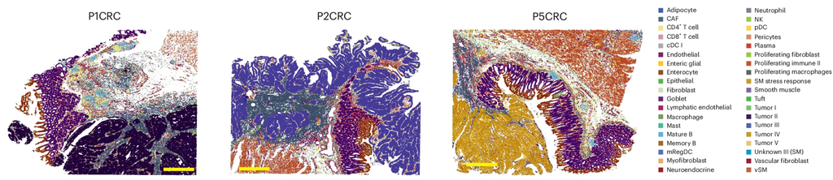

Figure 1: Cell type annotation overlaid on three colorectal samples sequenced with Visium HD.  
*Image source: [Oliveira et al. (2025)](https://www.nature.com/articles/s41588-025-02193-3)*

In particular, we are going to be working with the **P5CRC** colorectal cancer sample as there is a matched, normal adjacent **P5NAT** sample that we can use to compare tumor versus normal tissue.

**Dataset availability**

This dataset was generated by 10X Genomics and is publicly available on their website [here](https://www.10xgenomics.com/platforms/visium/product-family/dataset-human-crc).

### Metadata

While it may be tempting to get started right away with loading your data, it is crucial that you first take a moment to document metadata that is associated with your dataset. This information will be important for you to interpret your results correctly as you move further along in your analysis.

For this particular dataset, we have the following metadata available to us about the patient:

- Stage IV-A of CRC
- Female patient
- 58 years old

Additionally, we want to keep track of some basic information that we would expect to see in our dataset, more specifically the cell types we anticipate seeing:

- B cells
- Endothelial cells
- Fibroblasts
- Intestinal epithelial cells
- Myeloid cells
- Neural cells
- Smooth muscle cells
- T cells
- Tumor cells

**Sample preparation**

It is also good to keep track of the sample preparation and sequencing protocols that were used to generate the data. For this dataset, we know:

- 5 µm sections were taken from the FFPE tissue blocks with a microtome
- Sectioning followed the Visium CytAssist v2 WT Panel Gene Expression protocol
- FFPE tissue sections were placed on plain glass slides for deparaffinization, H&E staining and imaging following the Visium HD FFPE Tissue Preparation Handbook
- Sequencing was performed on an Illumina NovaSeq 6000 with paired-end reads
- Samples were processed with Space Ranger v3.0

**Exercise 1**

1. Given the information that we know from the metadata, what might be some questions that we want to answer using our data?
2. What are some of the limitations of this dataset that we should keep in mind as we analyze it?

With this information in mind, we can now move forward with loading our data and performing our analysis.